# ML Lab 07 - 25062022 - Questions

#### What is Stride, padding and pooling? Explain with an example

#### Stride

When the array is created, the pixels are shifted over to the input matrix. The number of pixels turning to the input matrix is known as strides. When the number of strides is 1, we move the filters to 1 pixel at a time. Similarly, when the number of strides is 2, we carry the filters to 2 pixels, and so on.

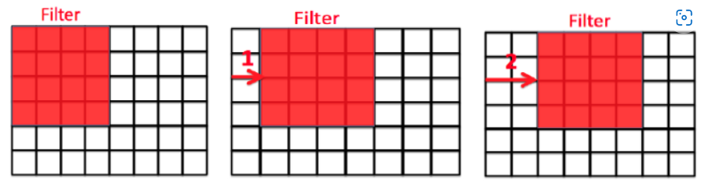

#### Padding

Padding is an additional layer that can add to the borders of an image while preserving the original size.

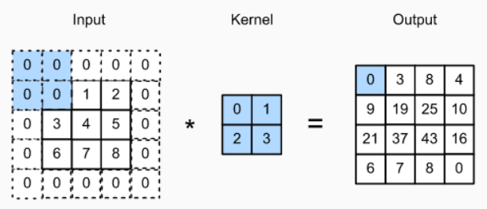

#### Pooling

There are three types of spatial pooling

1. Max Pooling

It takes the maximum value of a region

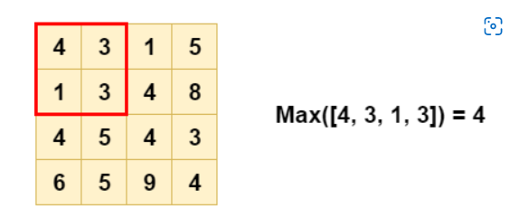

1. Average Pooling

It takes the average values of that particular region

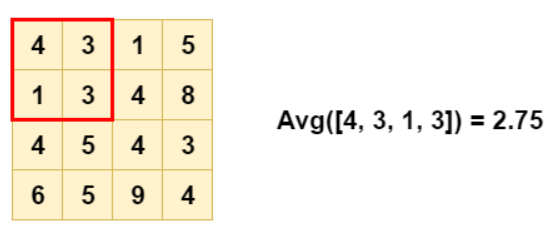

1. Sum Pooling

It takes the sum of all the values in that particular region

Link : https://www.codingninjas.com/codestudio/library/convolution-layer-padding-stride-and-pooling-in-cnn

#### What is overfitting? How to overcome overfitting in an ML model?

What is overfitting?

Overfitting occurs when a statistical model fits exactly against its training data. When this happens, the algorithm does not perform accurately against unseen data.

How to prevent overfitting

1. Cross-validation:

Use your training data to generate multiple mini train-test spilts. Use these splits to tune your model. Cross-validation allows you to tune hyperparameters with only your original training set.

1. Train with more data:

Training with more data help algorithms detect the signal better. We should ensure that the data is clean and relevant.

1. Remove features:
2. Early stopping:

Early stopping refers stopping the training process before the learner passes that point.

1. Regularization:

Regularization refers to a broad range of techniques for artificially forcing your model to be simpler.

1. Ensembling:

Ensembels are ML methods that combine predictions from multiple seperate models.

Two methods include bagging and boosting.

Links :

https://elitedatascience.com/overfitting-in-machine-learning